# Análisis de idoneidad de hábitat para manatíes utilizando el proceso analítico jerárquico y técnicas geoespaciales. Fuentes geoespaciales

# Introducción

El hábitat es un determinante fundamental para la supervivencia y prosperidad de cualquier especie animal. En el caso de los manatíes, animales acuáticos sumamente vulnerables, la preservación de su hábitat es crítica para su supervivencia. Sin embargo, la evaluación precisa del hábitat de los manatíes plantea retos debido a la falta de un marco analítico sistemático y a la carencia de herramientas adecuadas para tal fin.

En este estudio, abordamos estos desafíos mediante la aplicación del Proceso Analítico Jerárquico (AHP, por sus siglas en inglés) y técnicas geoespaciales para el análisis de idoneidad del hábitat para manatíes (Thomas L. Saaty 2001; Thomas L. Saaty y Tran 2007; Thomas L. Saaty 1977). El AHP es una técnica multicriterio que facilita la toma de decisiones en situaciones complejas, permitiendo la descomposición de un problema en un sistema de jerarquías. En el ámbito de la conservación de la vida silvestre, esta técnica puede ser invaluable para evaluar y priorizar áreas de hábitat basándose en diversos factores que contribuyen a la idoneidad del hábitat.

Además, las técnicas geoespaciales, como los Sistemas de Información Geográfica (SIG) y el Análisis Espacial, permiten la representación visual y la manipulación de los datos de ubicación. Estas técnicas, combinadas con el AHP, proporcionan un enfoque potente para la evaluación de la idoneidad del hábitat de los manatíes.

En resumen, este estudio busca proporcionar un marco integral y metodológicamente sólido para la evaluación de la idoneidad del hábitat de los manatíes. Con la adopción de herramientas sencillas y accesibles, como QGIS, y la incorporación de técnicas avanzadas como el AHP y el análisis espacial, esperamos que esta investigación contribuya significativamente al campo de la conservación de manatíes y a la gestión efectiva de sus hábitats.

# Materiales, métodos y resultados

## Paquetes y funciones

Esta parte del código es reaprovechable. Gran parte del código posterior depende de ella.

```r
library(terra)
library(sf)
library(kableExtra)
library(tidyverse)
library(gdalUtilities)
library(rgrass)
estilo_kable <- function(df, titulo = '', cubre_anchura = T) {
  df %>% kable(format = 'html', escape = F, booktabs = T, digits = 2, caption = titulo) %>%
  kable_styling(bootstrap_options = c("hover", "condensed"), full_width = cubre_anchura)
}
grass_flags <- c('overwrite', 'quiet')
ruta_fuentes <- 'fuentes/MAPA 1_HABITAT OPTIMO/'
```

También reaprovechable: reabrir la región de GRASS GIS

```r
gisdbase <- 'bdgrass' #Base de datos de GRASS GIS
wd <- getwd() #Directorio de trabajo
wd
```

```
## [1] "/media/jose/datos/tesis-valeria-herrera/repo-gh/manaties-rd"
```

```r
loc <- initGRASS(gisBase = "/usr/lib/grass82",
                 home = wd,
                 SG = bat,
                 gisDbase = paste(wd, gisdbase, sep = '/'),
                 location = 'rd',
                 mapset = "PERMANENT",
                 override = TRUE)
gmeta(g.proj_WKT = F) # Imprime información sobre la región activa de GRASS GIS
```

```
## gisdbase    /media/jose/datos/tesis-valeria-herrera/repo-gh/manaties-rd/bdgrass
## location    rd
## mapset      PERMANENT
## rows        2953
## columns     4004
## north       2214300
## south       1919000
## west        180300
## east        580700
## nsres       100
## ewres       100
## projection  +proj=utm +zone=19 +datum=WGS84 +units=m +no_defs +type=crs
```

## Preparación de los datos base

```r
ruta_bat <- paste0(ruta_fuentes, 'BatimetriaSRC.tif')
ruta_bat_utm <- paste0(ruta_fuentes, 'BatimetriaSRC_32619.tif')
```

```r
unzip(
  zipfile = paste0(ruta_fuentes, 'BatimetriaSRC.zip'),
  exdir = ruta_fuentes, junkpaths = T,
  unzip = '/usr/bin/unzip')
gdalwarp(
  srcfile = ruta_bat,
  dstfile = ruta_bat_utm,
  t_srs = 'EPSG:32619', # CRS de destino
  tr = c(100, 100), # Resolución de destino
  tap = TRUE, # Alinear a la cuadricula
  r = 'med', # Remuestreo por medio de mediana
  overwrite = T)
# file.remove(ruta_bat)
```

Cargamos la capa a `R` como `SpatRast`.

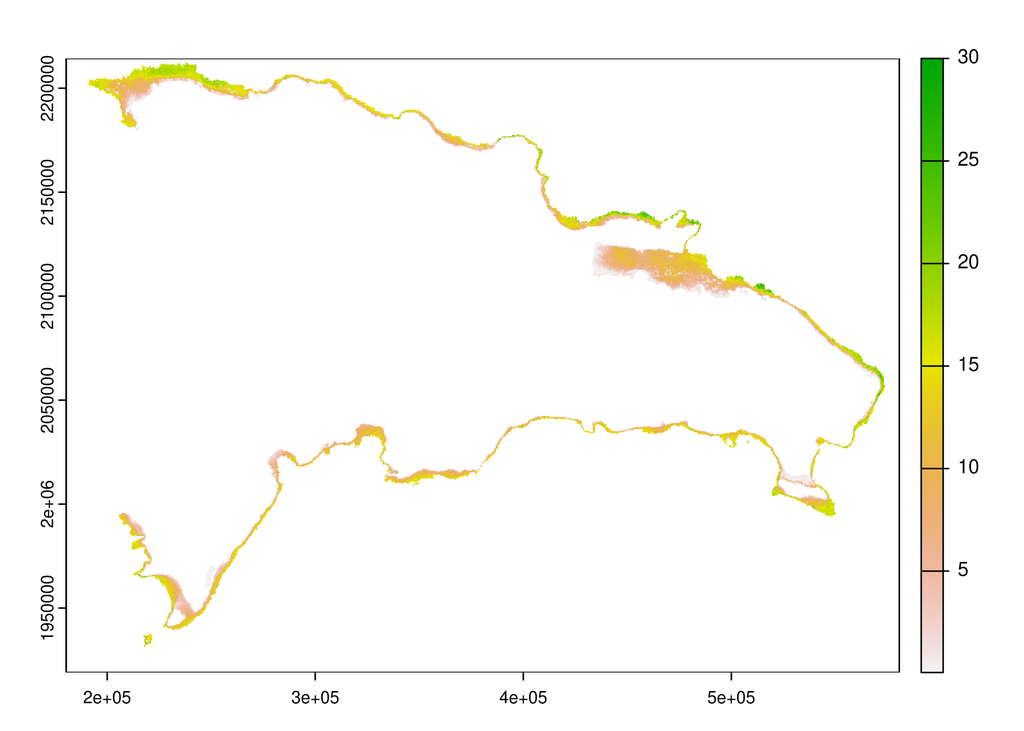

```r
bat <- rast(ruta_bat_utm)
plot(bat)
```

> IMPORTANTE. Ejecutar estas líneas SÓLO para cerrar la sesión de GRASS de forma apropiada. Útil al final del día, o antes de cerrar R. No es obligatorio hacerlo, más bien, es buena práctica.

```r
unlink_.gislock()
```

## Creación de base de datos GRASS GIS (GISDBASE/LOCATION/MAPSET)

Creamos la base de datos de GRASS GIS, con localización y conjunto de mapas incluido, usando la extensión y resolución de la capa de batimetría como base de definición (GRASS Development Team 2022).

```r
gisdbase <- 'bdgrass' #Base de datos de GRASS GIS
wd <- getwd() #Directorio de trabajo
wd
```

```
## [1] "/media/jose/datos/tesis-valeria-herrera/repo-gh/manaties-rd"
```

```r
loc <- initGRASS(gisBase = "/usr/lib/grass82",
                 home = wd,
                 SG = bat,
                 gisDbase = paste(wd, gisdbase, sep = '/'),
                 location = 'rd',
                 mapset = "PERMANENT",
                 override = TRUE)
gmeta(g.proj_WKT = F) # Imprime información sobre la región activa de GRASS GIS
```

```
## gisdbase    /media/jose/datos/tesis-valeria-herrera/repo-gh/manaties-rd/bdgrass
## location    rd
## mapset      PERMANENT
## rows        2953
## columns     4004
## north       2214300
## south       1919000
## west        180300
## east        580700
## nsres       100
## ewres       100
## projection  +proj=utm +zone=19 +datum=WGS84 +units=m +no_defs +type=crs
```

## Importar fuentes a GRASS GIS

### Capa de batimetría

Importamos el ráster con `r.import`.

```r
# system('r.import --help') # Ayuda sobre la función
execGRASS(
  cmd = 'r.import',
  flags = grass_flags,
  input = ruta_bat_utm,
  output = 'batimetria')
```

Fijar máscara.

```r
execGRASS(
  cmd = 'r.mask',
  flags = grass_flags,
  raster = 'batimetria')
system('g.list type=rast')
```

Representar, trayendo capa desde GRASS.

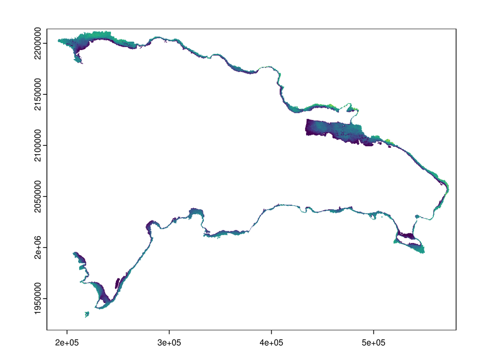

```r
bat_g <- read_RAST('batimetria', flags = grass_flags)
plot(bat_g)
```

### Capa de praderas

Extraer de ZIP.

```r
ruta_prad <- paste0(ruta_fuentes, 'PraderasSRC.shp')
ruta_prad_utm <- paste0(ruta_fuentes, 'PraderasSRC_32619.gpkg')
```

```r
unzip(
  zipfile = paste0(ruta_fuentes, 'PraderasSRC.zip'),
  exdir = ruta_fuentes, junkpaths = T,
  unzip = '/usr/bin/unzip')
ogr2ogr(
  src_datasource_name = ruta_prad,
  dst_datasource_name = ruta_prad_utm,
  s_srs = 'EPSG:4326', # CRS de origen
  t_srs = 'EPSG:32619', # CRS de destino
  f = 'GPKG',
  nlt = 'MULTIPOLYGON',
  overwrite = T)
# file.remove(paste0(gsub('.shp', '.', ruta_prad), c('dbf', 'prj', 'shp', 'shx')))
```

Importar a GRASS GIS.

```r
system('v.import --help')
execGRASS(
  cmd = 'v.import',
  flags = grass_flags,
  input = ruta_prad_utm,
  output = 'praderas')
```

Convertir a ráster.

```r
system('v.to.rast --help')
execGRASS(
  cmd = 'v.to.rast',
  flags = grass_flags,
  input = 'praderas',
  output = 'praderas',
  use = 'cat')
```

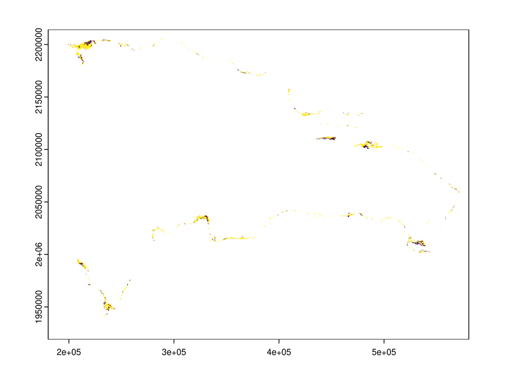

```r
prad_g <- read_RAST('praderas', flags = grass_flags)
plot(prad_g)
```

### Capa de estuarios

Extraer de ZIP.

```r
ruta_estu <- paste0(ruta_fuentes, 'EstuariosSRC.shp')
ruta_estu_utm <- paste0(ruta_fuentes, 'EstuariosSRC_32619.gpkg')
```

```r
unzip(
  zipfile = paste0(ruta_fuentes, 'EstuariosSRC.zip'),
  exdir = ruta_fuentes, junkpaths = T,
  unzip = '/usr/bin/unzip')
ogr2ogr(
  src_datasource_name = ruta_estu,
  dst_datasource_name = ruta_estu_utm,
  s_srs = 'EPSG:4326', # CRS de origen
  t_srs = 'EPSG:32619', # CRS de destino
  f = 'GPKG',
  nlt = 'MULTIPOLYGON',
  overwrite = T)
# file.remove(paste0(gsub('.shp', '.', ruta_estu), c('cpg', 'dbf', 'prj', 'shp', 'shx')))
```

Importar a GRASS GIS.

```r
system('v.import --help')
execGRASS(
  cmd = 'v.import',
  flags = grass_flags,
  input = ruta_estu_utm,
  output = 'estuarios')
```

Convertir a ráster.

```r
system('v.to.rast --help')
execGRASS(
  cmd = 'v.to.rast',
  flags = grass_flags,
  input = 'estuarios',
  output = 'estuarios',
  use = 'val')
```

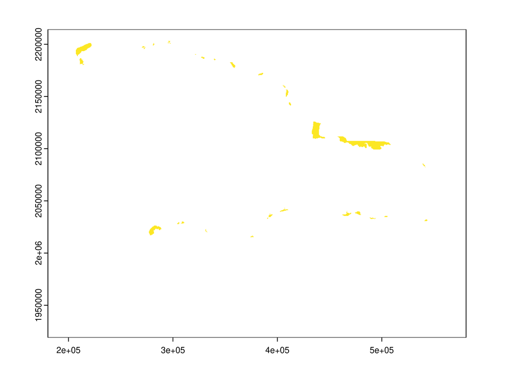

```r
estu_g <- read_RAST('estuarios', flags = grass_flags)
plot(estu_g)
```

### Capa de lagunas costeras

Extraer de ZIP.

```r
ruta_lagu <- paste0(ruta_fuentes, 'LagunasCosterasSRC.shp')
ruta_lagu_utm <- paste0(ruta_fuentes, 'LagunasCosterasSRC_32619.gpkg')
```

```r
unzip(
  zipfile = paste0(ruta_fuentes, 'LagunasCosterasSRC.zip'),
  exdir = ruta_fuentes, junkpaths = T,
  unzip = '/usr/bin/unzip')
ogr2ogr(
  src_datasource_name = ruta_lagu,
  dst_datasource_name = ruta_lagu_utm,
  s_srs = 'EPSG:4326', # CRS de origen
  t_srs = 'EPSG:32619', # CRS de destino
  f = 'GPKG',
  nlt = 'MULTIPOLYGON',
  overwrite = T)
# file.remove(paste0(gsub('.shp', '.', ruta_lagu), c('cpg', 'dbf', 'prj', 'shp', 'shx')))
```

Importar a GRASS GIS.

```r
system('v.import --help')
execGRASS(
  cmd = 'v.import',
  flags = grass_flags,
  input = ruta_lagu_utm,
  output = 'lagunas_costeras')
```

Convertir a ráster.

```r
system('v.to.rast --help')
execGRASS(
  cmd = 'v.to.rast',
  flags = grass_flags,
  input = 'lagunas_costeras',
  output = 'lagunas_costeras',
  use = 'val')
```

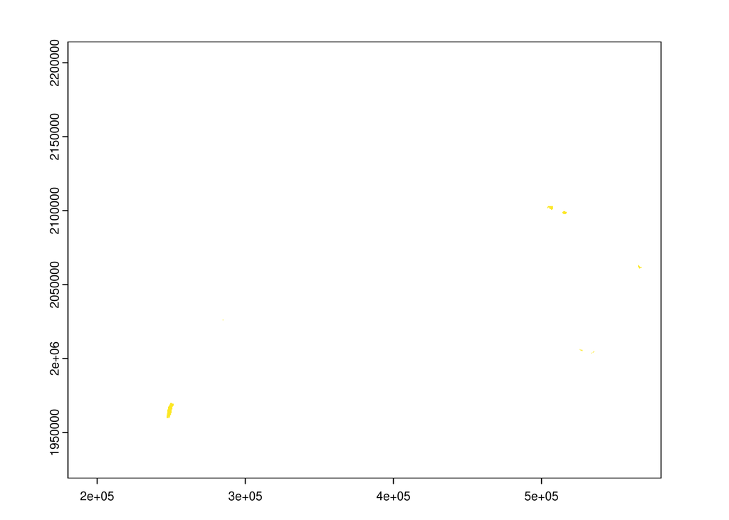

```r
lagu_g <- read_RAST('lagunas_costeras', flags = grass_flags)
plot(lagu_g)
```

### Capa de manglares

```r
ruta_mang <- paste0(ruta_fuentes, '../MASCARAS GENERADAS POR JR/global_mangrove_watch_union.tif')
ruta_mang_utm <- paste0(ruta_fuentes, '../MASCARAS GENERADAS POR JR/global_mangrove_watch_union_32619.tif')
```

Importamos el ráster con `r.import`.

```r
# system('r.import --help') # Ayuda sobre la función
execGRASS(
  cmd = 'r.import',
  flags = grass_flags,
  input = ruta_mang,
  output = 'manglares',
  extent = 'region',
  resolution = 'region')
```

Representar, trayendo capa desde GRASS.

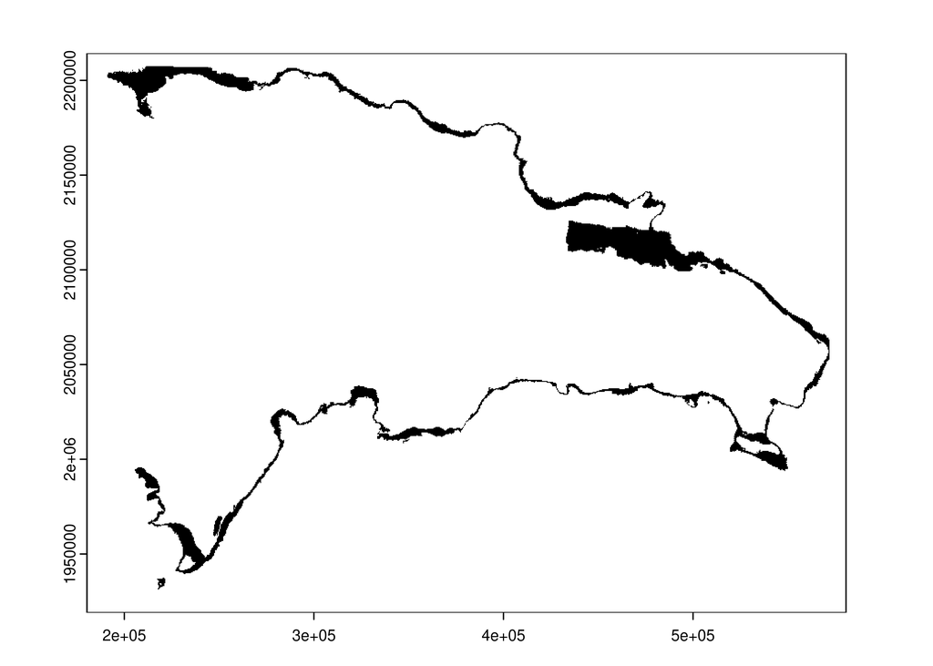

```r
mang_g <- read_RAST('manglares', flags = grass_flags)
plot(mang_g)
```

## Generar fuentes derivadas

### Distancia a praderas

```r
# system('r.grow.distance --help') # Ayuda sobre la función
execGRASS(
  cmd = 'r.grow.distance',
  flags = grass_flags,
  input = 'praderas',
  distance = 'praderas_distancias')
```

Representar, trayendo capa desde GRASS.

```r
prad_d_g <- read_RAST('praderas_distancias', flags = grass_flags)
```

```
## ADVERTENCIA: Too many values, color table cut to 65535 entries
```

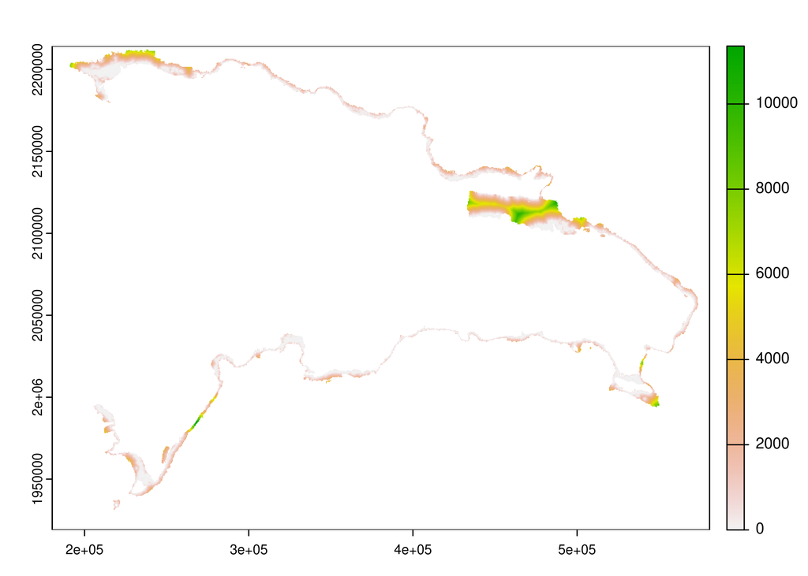

```r
plot(prad_d_g)
```

### Distancia a estuarios

```r
execGRASS(
  cmd = 'r.grow.distance',
  flags = grass_flags,
  input = 'estuarios',
  distance = 'estuarios_distancias')
```

Representar, trayendo capa desde GRASS.

```r
estu_d_g <- read_RAST('estuarios_distancias', flags = grass_flags)
```

```
## ADVERTENCIA: Too many values, color table cut to 65535 entries
```

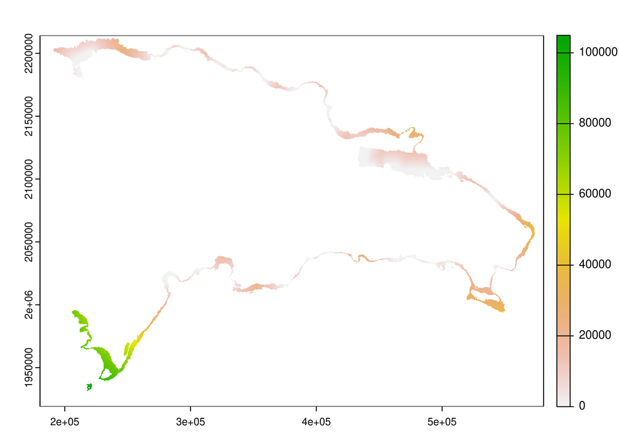

```r
plot(estu_d_g)
```

### Distancia a manglares

```r
execGRASS(
  cmd = 'r.grow.distance',
  flags = grass_flags,
  input = 'manglares',
  distance = 'manglares_distancias')
```

Representar, trayendo capa desde GRASS.

```r
mang_d_g <- read_RAST('manglares_distancias', flags = grass_flags)
```

```
## ADVERTENCIA: Too many values, color table cut to 65535 entries
```

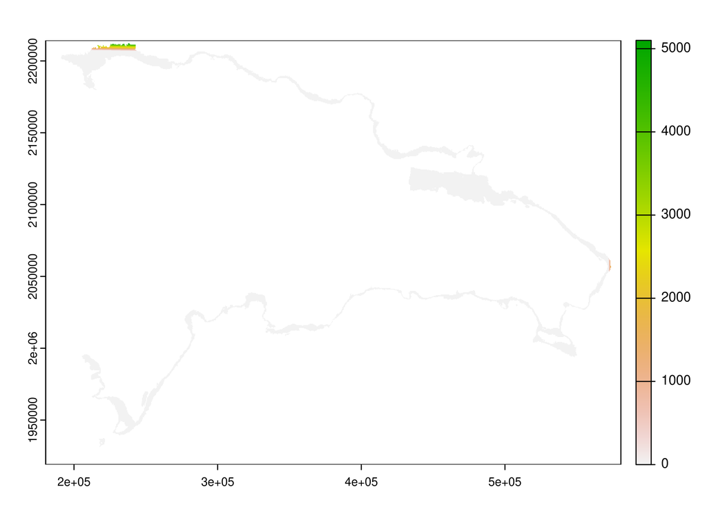

```r
plot(mang_d_g)
```

## Cierre de la sesión de GRASS GIS

```r
unlink_.gislock()
```

# Referencias

GDAL/OGR contributors. 2022. *GDAL/OGR Geospatial Data Abstraction software Library*. Open Source Geospatial Foundation. https://doi.org/10.5281/zenodo.5884351.

GRASS Development Team. 2022. *Geographic Resources Analysis Support System (GRASS) Software, Version 8.0.2*. USA: Open Source Geospatial Foundation. https://grass.osgeo.org.

Saaty, Thomas L. 1977. «A Scaling Method for Priorities in Hierarchical Structures». *Journal of Mathematical Psychology* 15 (3): 234-81. https://doi.org/10.1016/0022-2496(77)90033-5.

Saaty, Thomas L. 2001. «Fundamentals of the Analytic Hierarchy Process». En, editado por Daniel L. Schmoldt, Jyrki Kangas, Guillermo A. Mendoza, y Mauno Pesonen, 3:15-35. Dordrecht: Springer Netherlands. http://link.springer.com/10.1007/978-94-015-9799-9_2.

Saaty, Thomas L., y Liem T. Tran. 2007. «On the Invalidity of Fuzzifying Numerical Judgments in the Analytic Hierarchy Process». *Mathematical and Computer Modelling* 46 (7-8): 962-75. https://doi.org/10.1016/j.mcm.2007.03.022.